# Bellabeat_CS

Diego Barón

2024-08-18

## First load the necessary libraries

```r
library("tidyverse")
```

```r
library("ggplot2")
library("skimr")
library("janitor")
library("dplyr")
library("here")
```

## Now the import of the datasets

For my case of study I decided to focus on the Time watch which tracks activity, sleep and stress, is worth to make clear that according to some studies from medical papers the stress can be measure by the heart rate, that’s not the only factor that contributes to the stress but is a critical point to detect it and that’s why I will be using the Activity data set, the sleep data set and the hearth rate data set.

```r
activity <- read_csv("dailyActivity_merged.csv")
sleep <- read_csv("minuteSleep_merged.csv")
stress <- read_csv("heartrate_seconds_merged.csv")
```

## Preparation of the data sets

First lets see some statics of our data sets:

```r
summary(activity)
```

```
##        Id            ActivityDate         TotalSteps    TotalDistance
##  Min.   :1.504e+09   Length:457         Min.   :    0   Min.   : 0.000
##  1st Qu.:2.347e+09   Class :character   1st Qu.: 1988   1st Qu.: 1.410
##  Median :4.057e+09   Mode  :character   Median : 5986   Median : 4.090
##  Mean   :4.629e+09                      Mean   : 6547   Mean   : 4.664
##  3rd Qu.:6.392e+09                      3rd Qu.:10198   3rd Qu.: 7.160
##  Max.   :8.878e+09                      Max.   :28497   Max.   :27.530
##  TrackerDistance LoggedActivitiesDistance VeryActiveDistance
##  Min.   : 0.00   Min.   :0.0000           Min.   : 0.000
##  1st Qu.: 1.28   1st Qu.:0.0000           1st Qu.: 0.000
##  Median : 4.09   Median :0.0000           Median : 0.000
##  Mean   : 4.61   Mean   :0.1794           Mean   : 1.181
##  3rd Qu.: 7.11   3rd Qu.:0.0000           3rd Qu.: 1.310
##  Max.   :27.53   Max.   :6.7271           Max.   :21.920
##  ModeratelyActiveDistance LightActiveDistance SedentaryActiveDistance
##  Min.   :0.0000           Min.   : 0.00       Min.   :0.000000
##  1st Qu.:0.0000           1st Qu.: 0.87       1st Qu.:0.000000
##  Median :0.0200           Median : 2.93       Median :0.000000
##  Mean   :0.4786           Mean   : 2.89       Mean   :0.001904
##  3rd Qu.:0.6700           3rd Qu.: 4.46       3rd Qu.:0.000000
##  Max.   :6.4000           Max.   :12.51       Max.   :0.100000
##  VeryActiveMinutes FairlyActiveMinutes LightlyActiveMinutes SedentaryMinutes
##  Min.   :  0.00    Min.   :  0.00      Min.   :  0.0        Min.   :  32.0
##  1st Qu.:  0.00    1st Qu.:  0.00      1st Qu.: 64.0        1st Qu.: 728.0
##  Median :  0.00    Median :  1.00      Median :181.0        Median :1057.0
##  Mean   : 16.62    Mean   : 13.07      Mean   :170.1        Mean   : 995.3
##  3rd Qu.: 25.00    3rd Qu.: 16.00      3rd Qu.:257.0        3rd Qu.:1285.0
##  Max.   :202.00    Max.   :660.00      Max.   :720.0        Max.   :1440.0
##     Calories
##  Min.   :   0
##  1st Qu.:1776
##  Median :2062
##  Mean   :2189
##  3rd Qu.:2667
##  Max.   :4562
```

```r
summary(sleep)
```

```
##        Id                date               value           logId
##  Min.   :1.504e+09   Length:198559      Min.   :1.000   Min.   :1.110e+10
##  1st Qu.:2.347e+09   Class :character   1st Qu.:1.000   1st Qu.:1.117e+10
##  Median :4.703e+09   Mode  :character   Median :1.000   Median :1.124e+10
##  Mean   :4.824e+09                      Mean   :1.086   Mean   :1.124e+10
##  3rd Qu.:6.776e+09                      3rd Qu.:1.000   3rd Qu.:1.131e+10
##  Max.   :8.792e+09                      Max.   :3.000   Max.   :1.137e+10
```

```r
summary(stress)
```

```
##        Id                Time               Value
##  Min.   :2.022e+09   Length:1154681     Min.   : 36.00
##  1st Qu.:4.020e+09   Class :character   1st Qu.: 66.00
##  Median :5.554e+09   Mode  :character   Median : 77.00
##  Mean   :5.352e+09                      Mean   : 79.76
##  3rd Qu.:6.962e+09                      3rd Qu.: 90.00
##  Max.   :8.878e+09                      Max.   :185.00
```

The first thing to notice is that the date in all data sets are in MM/DD/YYYY format also they are not recognized as dates but character type of data and on the sleep and stress data sets the date is long date meaning it also have a time stamp, so lets start by formatting our data. ### More data statics Now lets check the data sets for unique participants

```r
n_distinct(activity$Id)
```

```
## [1] 35
```

```r
n_distinct(sleep$Id)
```

```
## [1] 23
```

```r
n_distinct(stress$Id)
```

```
## [1] 14
```

With this new set of statics we can see that:

- The Activity data set have 35 participants
- The Sleep data set have 23 participants
- The Stress data set have 14 participants

## Data Formatting

Now with this first statics let’s start with the formatting of the date field in every data set:

```r
activity$ActivityDate=as.POSIXct(activity$ActivityDate, format="%m/%d/%Y", tz=Sys.timezone())
sleep$date=as.POSIXct(sleep$date, format="%m/%d/%Y %I:%M:%S", tz="")
sleep$shortDate <- format(sleep$date, format = "%m/%d/%y")
stress$Time=as.POSIXct(stress$Time, format="%m/%d/%Y %I:%M:%S", tz="")
stress$shortDate <- format(stress$Time, format = "%m/%d/%y")
```

With this I completed the formatting of the dates as well to include an extra separate column in sleep and stress data set for the time and date, this is important later on for analysis purposes.

## More statistics

Now lets make some summaries for data in each data set:

### Activity data set

```r
activity %>%
  select(TotalSteps,TotalDistance,SedentaryMinutes,Calories) %>% summary()
```

```
##    TotalSteps    TotalDistance    SedentaryMinutes    Calories
##  Min.   :    0   Min.   : 0.000   Min.   :  32.0   Min.   :   0
##  1st Qu.: 1988   1st Qu.: 1.410   1st Qu.: 728.0   1st Qu.:1776
##  Median : 5986   Median : 4.090   Median :1057.0   Median :2062
##  Mean   : 6547   Mean   : 4.664   Mean   : 995.3   Mean   :2189
##  3rd Qu.:10198   3rd Qu.: 7.160   3rd Qu.:1285.0   3rd Qu.:2667
##  Max.   :28497   Max.   :27.530   Max.   :1440.0   Max.   :4562
```

```r
activity %>%
  select(VeryActiveMinutes,FairlyActiveMinutes,LightlyActiveMinutes) %>% summary()
```

```
##  VeryActiveMinutes FairlyActiveMinutes LightlyActiveMinutes
##  Min.   :  0.00    Min.   :  0.00      Min.   :  0.0
##  1st Qu.:  0.00    1st Qu.:  0.00      1st Qu.: 64.0
##  Median :  0.00    Median :  1.00      Median :181.0
##  Mean   : 16.62    Mean   : 13.07      Mean   :170.1
##  3rd Qu.: 25.00    3rd Qu.: 16.00      3rd Qu.:257.0
##  Max.   :202.00    Max.   :660.00      Max.   :720.0
```

This first selective summaries show us some insights:

*The mean total steps are 6547* The mean total distance traveled is 4.664 miles *The mean sedentary time in minutes are 995.3 mins (16.58 hrs aprox.)* The mean of very active (intense) activity minutes is 16.62 mins *The mean of fairly active activity is 13.07 mins* The mean of light activity in minutes is 170.1 mins (2.8 hrs aprox.) *This means that most of the steps and distance traveled is during light activity

### Sleep data set

```r
sleepDF <- sleep %>%
  group_by(Id) %>%
  summarize(totalMinutes = sum(value),
            averageHours = totalMinutes/60 ,
            MeasuredDays = n_distinct(shortDate),
            bedTimeDay = averageHours/MeasuredDays)
```

Further I will return to this summary to get other insights such as *average bed time per day*, *average days of usage* and *average hours slept*, for now lets see a similar summary but for the heart rate data set.

### Heart rate (Stress) data set

```r
stressDF <- stress %>%
  group_by(Id) %>%
  summarize(MeasuredDays = n_distinct(shortDate), averageHeartRateDay = sum(Value)/MeasuredDays)
```

*The increase in the heart rate is due to high activity levels* The most of the participants of the heart rate data set also have the most sleep hours

## Activity and Stress Merge

```r
activityMerged <- merge(stressDF,activity, by = c('Id'))
head(activityMerged)
```

```
##           Id MeasuredDays averageHeartRateDay ActivityDate TotalSteps
## 1 2022484408           13              354924   2016-04-10      10005
## 2 2022484408           13              354924   2016-04-02       5477
## 3 2022484408           13              354924   2016-04-08      13023
## 4 2022484408           13              354924   2016-04-09      16267
## 5 2022484408           13              354924   2016-04-01      13603
## 6 2022484408           13              354924   2016-04-07      18247
##   TotalDistance TrackerDistance LoggedActivitiesDistance VeryActiveDistance
## 1          7.02            7.02                        0               0.08
## 2          3.84            3.84                        0               0.00
## 3          9.26            9.26                        0               3.23
## 4         12.59           12.59                        0               5.75
## 5          9.60            9.60                        0               5.46
## 6         13.83           13.83                        0               7.11
##   ModeratelyActiveDistance LightActiveDistance SedentaryActiveDistance
```

[output cut: 20 more lines]

## Sleep and Stress Merge

```r
mergedData <- merge(stressDF,sleepDF, by = c('Id'))
head(mergedData)
```

```
##           Id MeasuredDays.x averageHeartRateDay totalMinutes averageHours
## 1 2022484408             13            354924.0          153       2.5500
## 2 2026352035              1             28877.0        18848     314.1333
## 3 2347167796             15            612627.2        14940     249.0000
## 4 4020332650             13           1787941.5         6101     101.6833
## 5 4558609924             13            424313.6          666      11.1000
## 6 5553957443             13            522226.9        16231     270.5167
##   MeasuredDays.y bedTimeDay
## 1              1   2.550000
## 2             34   9.239216
## 3             32   7.781250
## 4             16   6.355208
## 5              5   2.220000
## 6             31   8.726344
```

## Making visualitation

With the merged data lets create a visualization

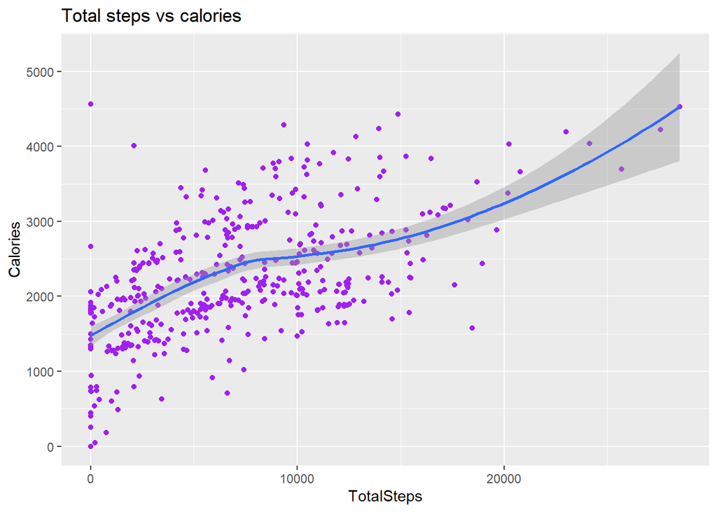

As we can se from this graph the calories burned are not always related to steps done, as we can see the calories burned tend to concentrate between 0 to 10,000 steps.

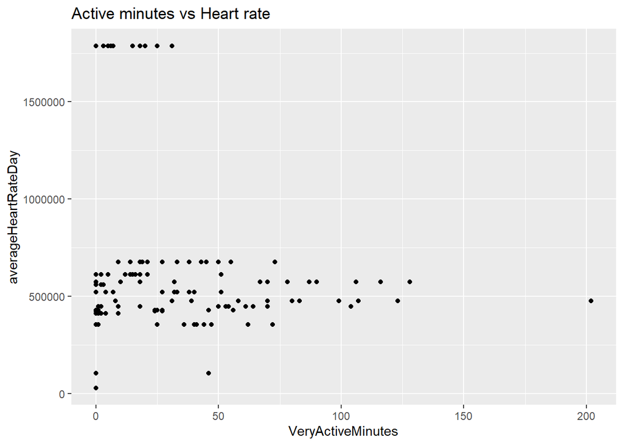

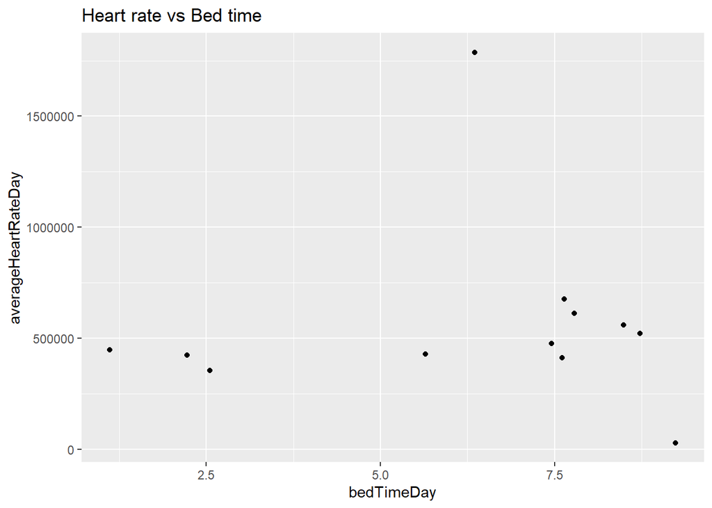

Unfortunately the second hypothesis is inconclusive due to the lack of data, there is so little cases of study to detect a trend or pattern.

## Key takeaways

Now for the product I selected the *Time* watch, seeing the lack of sleep data I would recommend to conduct a survey about the design and comfort wearing the device because maybe the reason is that people in general does not feel comfortable gearing traditional design watches to sleep causing to put them away to sleep, also I would recommend to look into the sensors, their sensitivity, accuracy, isolation to prevent water or sweat to damage the sensors.